# Lista 3 - Exercício 1 (Modelo de Gerações Sobrepostas)

#### Considere o Modelo de Gerações Sobrepostas discutido em aula. Os indivíduos que nascem com riqueza $a_1$ e possuem trajetória de renda ao longo da vida dada por $\{y_t\}^T_{t=1}$ resolvem problema de maximização apresentado em (1)

\begin{align*} W\left( a_1, \{y_t\}^T_{t=1} \right) &\equiv \max_{(c_t, a_{t+1})^T_{t=1}}\left\{ \sum^T_{t=1}{\beta^{t-1} u(c_t)} \right\} \tag{1} \\ &\qquad \text{s.a. } \left\{ \begin{array}{l} c_t = y_t + (1 + r_t) a_t - a_{t+1} \ge 0 \\ a_{t+1} \ge -\bar{A} \end{array} \right. \tag{2} \end{align*}

#### em que $r_t$ denota a taxa de juros no período $t$, $T$ denota o horizonte de vida dos indivíduos e a utilidade instantânea é dada por

$$u(c) = (c^{1-\delta} - 1) / (1 - \delta).$$

#### Conforme discutido em aula, usando a definição da função valor $V_t(a_t)$ do período $t \in \{1, 2, ..., T\}$, a seguir: $$ V_t(a_t) \equiv \max_{-\bar{A} \le a_{t+1} \le y_t + a_t} \bigg\{ u[y_t + (1 + r_t) a_t - a_{t+1}] + \beta V_{t+1}(a_{t+1}) \bigg\} \tag{3} $$ e $V_{T+1}(a_{T+1}) = 0$, tem-se $W\left( a_1, \{y_t\}^T_{t=1} \right) = V_1(a_1)$.

#### Em cada período $s \in \mathbb{N} \equiv \{0, 1, 2, 3, ...\}$, há $T$ gerações de indivíduos presentes na economia. Há $1/T$ indivíduos nascidos no período $s$, os quais compõem a denominada geração $s$ e estão em seu primeiro período de vida ($t = 1$). Similarmente, há $1/T$ indivíduos presentes na economia em $s$, mas que nasceram no período $s-1$. Trata-se dos indivíduos da geração $s-1$, os quais estão no seu segundo período de vida ($t = 2$). Mais geralmente, para cada $t \in \{1, 2, ..., T\}$, há $1/T$ indivíduos presentes na economia no período $s$, mas que nasceram no período $s-t$. Trata-se, portanto, dos indivíduos da geração $s-t$, os quais estão no seu $t$-ésimo período de vida.

#### Supondo uma taxa de juros constante no tempo dada por $r = 0.04$ e que a renda de cada indivíduo é $y_t = 1$ se $t < 3T/4$ e $y_t = 0.1$ caso contrário, resolva os itens a seguir. Todos os programas precisam ser escritos em linguagem Python e todos os itens precisam ser resolvidos supondo $T = 10$, com a óbvia exceção do item (b).

### (a) Escreva um código que calcule a *função política* e a *função valor* dos indivíduos, usando como parâmetros do modelo os mesmos valores assumidos pelo professor em aula. Utilize o método de *Indução Retroativa* baseado no problema recursivo (3) combinado com o método de *Otimização por Discretização*.

```python
import numpy as np
import matplotlib.pyplot as plt

T = 10
n_a = 50
r_ini = .04

def resolve_OLG(r=r_ini, T=T, beta=.98, delta=2, a_max=2, n_a=n_a, A=0):
    """ (r, T, beta, delta, a_max, n_a, A) -> (V, iG, G) """
    global a_grid, y_grid

    # Função utilidade
    def u(c):
        """ c -> utilidade """
        return ( c**(1-delta) ) / ( 1 - delta)

    # Criando grids necessários
    a_grid = np.linspace(A, a_max, n_a)
    y_grid = np.zeros(T)

    for t in range(1, T+1):  # Começa em 1 e vai até T (range desconta 1 unidade)
        if t < 3 * T / 4:
            y_grid[t-1] = 1  # índice precisa subtrair 1
        else:
            y_grid[t-1] = .1  # índice precisa subtrair 1

    # Objetos para preencher com as funções valor e política (índice)
    V = np.zeros((n_a, T+1))  # Cria até T+1, pois usa uma "função valor" T+1 para multiplicar por 0 na função objetivo de T
    iG = np.zeros((n_a, T), dtype=np.int32)

    # Preenchendo e maximizando a função objetivo
    # Começando apenas do período T (índice T-1), e vai a 0 (range desconta 1 unidade)
    # Prof. Jefferson faz os cálculos em relação ao período seguinte
    for t in range(T-1, -1, -1):
        for i_a in range(n_a):
            F_OBJ = np.zeros((n_a, n_a))
            a = a_grid[i_a]

            for i_aa in range(n_a):
                aa = a_grid[i_aa]
                c = y_grid[t] + (1+r)*a - aa

                if c < 0:
                    F_OBJ[i_a, i_aa] = -np.inf
                else:
                    F_OBJ[i_a, i_aa] = u(c) + beta*V[i_aa, t+1]

            V[i_a, t] = np.max(F_OBJ[i_a,:])
            iG[i_a, t] = np.argmax(F_OBJ[i_a,:])

    V = V[:, 0:(len(V[0])-1)]  # Retirando a última coluna de zeros
    G = a_grid[iG]
    return V, iG, G
```

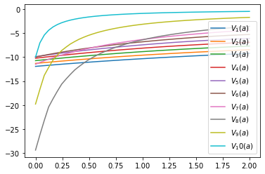

```python
## Atribuindo soluções para objetos
V, iG, G = resolve_OLG()

## Funções Valor
for t in range(len(V[0])):
    plt.plot(a_grid, V[:, t], "-", label=f"$V_{t+1}(a)$")
plt.legend()
```

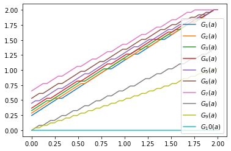

```python
## Funções Políticas
for t in range(len(G[0])):
    plt.plot(a_grid, G[:, t], "-", label=f"$G_{t+1}(a)$")
plt.legend()
```

### (b) Usando a função política obtida no item (a), estude e reporte a evolução da riqueza do indivíduo para cada $T \in \{2, 3, ..., 10\}$.

```
<function matplotlib.pyplot.show(close=None, block=None)>
```

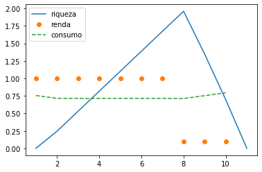

```python
## Estudando a evolução da riqueza de um indivíduo
ia_t = np.zeros(T+1, dtype=np.int32)
a_t = np.zeros(T+1)

ia_t[0] = 0  # Índice da riqueza inicial
a_t[0] = a_grid[ia_t[0]]

for t in range(1, T+1):
    ia_t[t] = iG[ia_t[t-1], t-1]
    a_t[t] = a_grid[ia_t[t]]


# calculando consumo para inserir no gráfico
c_t = np.zeros(T)
for i in range(T):
    c_t[i] = y_grid[i] + a_t[i] - a_t[i+1]


## Gráficos
figure, ax = plt.subplots()
plt.plot(range(1,T+2), a_t, label="riqueza")
""" Índice vai até T+2, pois escolhe a' = 0 no período final T, e Python subtrai 1 quando usa range() """

plt.plot(range(1,T+1), y_grid, "o", label="renda")
plt.plot(range(1,T+1), c_t, "--", label="consumo")
plt.legend(loc="best")
plt.show
```

### (c) Suponha a partir desse item que, inicialmente, a riqueza seja uniformemente distribuída entre os indivíduos, i.e. $\phi_0(a, t) = 1/T n_a$, em que $n_a \in \mathbb{N}$ é a quantidade de pontos usada no *grid* adotado para os níveis de riqueza $a_t$. Usando a função política encontrada no item (a), complemente o código do item (a) para obter um programa capaz de calcular a distribuição de riqueza no período $s = 1$ [ou seja, calcule $\phi_1(a, t)$ para cada $(a, t)$]. Utilize este programa para reportar qual é a massa de pessoas com idade $t = 1$ e com a menor riqueza presente no grid adotado para os níveis de riqueza $a_t$.

```python
phi_0 = np.ones((n_a, T)) / (T * n_a)
print("A distribuição inicial $\\phi_0$ é:\n", np.round(phi_0, 3),"\n")
```

```
A distribuição inicial $\phi_0$ é:
 [[0.002 0.002 0.002 0.002 0.002 0.002 0.002 0.002 0.002 0.002]
 [0.002 0.002 0.002 0.002 0.002 0.002 0.002 0.002 0.002 0.002]
 [0.002 0.002 0.002 0.002 0.002 0.002 0.002 0.002 0.002 0.002]
 [0.002 0.002 0.002 0.002 0.002 0.002 0.002 0.002 0.002 0.002]
 [0.002 0.002 0.002 0.002 0.002 0.002 0.002 0.002 0.002 0.002]
 [0.002 0.002 0.002 0.002 0.002 0.002 0.002 0.002 0.002 0.002]
 [0.002 0.002 0.002 0.002 0.002 0.002 0.002 0.002 0.002 0.002]
 [0.002 0.002 0.002 0.002 0.002 0.002 0.002 0.002 0.002 0.002]
 [0.002 0.002 0.002 0.002 0.002 0.002 0.002 0.002 0.002 0.002]
 [0.002 0.002 0.002 0.002 0.002 0.002 0.002 0.002 0.002 0.002]
 [0.002 0.002 0.002 0.002 0.002 0.002 0.002 0.002 0.002 0.002]
 [0.002 0.002 0.002 0.002 0.002 0.002 0.002 0.002 0.002 0.002]
 [0.002 0.002 0.002 0.002 0.002 0.002 0.002 0.002 0.002 0.002]
 [0.002 0.002 0.002 0.002 0.002 0.002 0.002 0.002 0.002 0.002]
 [0.002 0.002 0.002 0.002 0.002 0.002 0.002 0.002 0.002 0.002]
 [0.002 0.002 0.002 0.002 0.002 0.002 0.002 0.002 0.002 0.002]
 [0.002 0.002 0.002 0.002 0.002 0.002 0.002 0.002 0.002 0.002]
 [0.002 0.002 0.002 0.002 0.002 0.002 0.002 0.002 0.002 0.002]
 [0.002 0.002 0.002 0.002 0.002 0.002 0.002 0.002 0.002 0.002]
 [0.002 0.002 0.002 0.002 0.002 0.002 0.002 0.002 0.002 0.002]
 [0.002 0.002 0.002 0.002 0.002 0.002 0.002 0.002 0.002 0.002]
 [0.002 0.002 0.002 0.002 0.002 0.002 0.002 0.002 0.002 0.002]
 [0.002 0.002 0.002 0.002 0.002 0.002 0.002 0.002 0.002 0.002]
 [0.002 0.002 0.002 0.002 0.002 0.002 0.002 0.002 0.002 0.002]
 [0.002 0.002 0.002 0.002 0.002 0.002 0.002 0.002 0.002 0.002]
 [0.002 0.002 0.002 0.002 0.002 0.002 0.002 0.002 0.002 0.002]
 [0.002 0.002 0.002 0.002 0.002 0.002 0.002 0.002 0.002 0.002]
 [0.002 0.002 0.002 0.002 0.002 0.002 0.002 0.002 0.002 0.002]
 [0.002 0.002 0.002 0.002 0.002 0.002 0.002 0.002 0.002 0.002]
 [0.002 0.002 0.002 0.002 0.002 0.002 0.002 0.002 0.002 0.002]
 [0.002 0.002 0.002 0.002 0.002 0.002 0.002 0.002 0.002 0.002]
 [0.002 0.002 0.002 0.002 0.002 0.002 0.002 0.002 0.002 0.002]
 [0.002 0.002 0.002 0.002 0.002 0.002 0.002 0.002 0.002 0.002]
 [0.002 0.002 0.002 0.002 0.002 0.002 0.002 0.002 0.002 0.002]
 [0.002 0.002 0.002 0.002 0.002 0.002 0.002 0.002 0.002 0.002]
 [0.002 0.002 0.002 0.002 0.002 0.002 0.002 0.002 0.002 0.002]
 [0.002 0.002 0.002 0.002 0.002 0.002 0.002 0.002 0.002 0.002]
 [0.002 0.002 0.002 0.002 0.002 0.002 0.002 0.002 0.002 0.002]
 [0.002 0.002 0.002 0.002 0.002 0.002 0.002 0.002 0.002 0.002]
 [0.002 0.002 0.002 0.002 0.002 0.002 0.002 0.002 0.002 0.002]
 [0.002 0.002 0.002 0.002 0.002 0.002 0.002 0.002 0.002 0.002]
 [0.002 0.002 0.002 0.002 0.002 0.002 0.002 0.002 0.002 0.002]
 [0.002 0.002 0.002 0.002 0.002 0.002 0.002 0.002 0.002 0.002]
 [0.002 0.002 0.002 0.002 0.002 0.002 0.002 0.002 0.002 0.002]
 [0.002 0.002 0.002 0.002 0.002 0.002 0.002 0.002 0.002 0.002]
 [0.002 0.002 0.002 0.002 0.002 0.002 0.002 0.002 0.002 0.002]
 [0.002 0.002 0.002 0.002 0.002 0.002 0.002 0.002 0.002 0.002]
 [0.002 0.002 0.002 0.002 0.002 0.002 0.002 0.002 0.002 0.002]
 [0.002 0.002 0.002 0.002 0.002 0.002 0.002 0.002 0.002 0.002]
 [0.002 0.002 0.002 0.002 0.002 0.002 0.002 0.002 0.002 0.002]]
```

```python
# Calculando a distribuição no período seguinte
phi_1 = np.zeros((n_a, T))

for t in range(T):
    for i_a in range(n_a):
        medida = phi_0[i_a, t]  # proporção de pessoas em (i_a, t)
        i_aa = iG[i_a, t]  # riqueza para o próximo período escolhida pelas pessoas em (i_a, t)

        # Preenchendo a proporção para o próximo período de vida
        if t < T-1:
            phi_1[i_aa, t+1] += medida  # somando com o anterior, pois diferentes $a$ pode ir para um mesmo $a'$
        else:
            phi_1[i_aa, 0] += medida

print(f"A distribuição $\\phi_1$ :\n", np.round(phi_1, 3))
```

```
A distribuição $\phi_1$ :
 [[0.1   0.    0.    0.    0.    0.    0.    0.    0.002 0.002]
 [0.    0.    0.    0.    0.    0.    0.    0.    0.002 0.004]
 [0.    0.    0.    0.    0.    0.    0.    0.    0.004 0.004]
 [0.    0.    0.    0.    0.    0.    0.    0.    0.002 0.004]
 [0.    0.    0.    0.    0.    0.    0.    0.    0.004 0.004]
 [0.    0.    0.    0.    0.    0.    0.    0.    0.002 0.004]
 [0.    0.002 0.    0.    0.    0.    0.    0.    0.004 0.004]
 [0.    0.002 0.002 0.    0.    0.    0.    0.    0.002 0.004]
 [0.    0.002 0.002 0.002 0.    0.    0.    0.    0.004 0.004]
 [0.    0.002 0.002 0.002 0.002 0.    0.    0.    0.002 0.004]
 [0.    0.002 0.002 0.002 0.002 0.    0.    0.    0.004 0.004]
 [0.    0.002 0.002 0.002 0.002 0.002 0.    0.    0.002 0.004]
 [0.    0.002 0.002 0.004 0.002 0.004 0.    0.    0.004 0.004]
 [0.    0.004 0.004 0.002 0.004 0.002 0.002 0.    0.002 0.004]
 [0.    0.002 0.002 0.002 0.002 0.002 0.002 0.    0.004 0.004]
 [0.    0.002 0.002 0.002 0.002 0.002 0.004 0.    0.002 0.004]
 [0.    0.002 0.002 0.002 0.002 0.002 0.002 0.002 0.004 0.004]
 [0.    0.002 0.002 0.002 0.002 0.004 0.002 0.002 0.002 0.004]
 [0.    0.002 0.002 0.002 0.002 0.002 0.002 0.002 0.004 0.004]
 [0.    0.002 0.004 0.002 0.002 0.002 0.004 0.004 0.002 0.004]
 [0.    0.002 0.002 0.004 0.004 0.002 0.002 0.002 0.002 0.002]
 [0.    0.002 0.002 0.002 0.002 0.002 0.002 0.002 0.004 0.004]
 [0.    0.002 0.002 0.002 0.002 0.002 0.002 0.004 0.002 0.004]
 [0.    0.002 0.002 0.002 0.002 0.004 0.002 0.002 0.004 0.004]
 [0.    0.002 0.002 0.002 0.002 0.002 0.004 0.002 0.002 0.004]
 [0.    0.004 0.002 0.004 0.002 0.002 0.002 0.002 0.004 0.004]
 [0.    0.002 0.002 0.002 0.002 0.002 0.002 0.004 0.002 0.   ]
 [0.    0.002 0.002 0.002 0.004 0.002 0.002 0.002 0.004 0.   ]
 [0.    0.002 0.002 0.002 0.002 0.002 0.004 0.002 0.002 0.   ]
 [0.    0.002 0.004 0.002 0.002 0.004 0.002 0.004 0.004 0.   ]
 [0.    0.002 0.002 0.002 0.002 0.002 0.002 0.002 0.002 0.   ]
 [0.    0.004 0.002 0.002 0.004 0.002 0.002 0.002 0.004 0.   ]
 [0.    0.002 0.002 0.002 0.002 0.002 0.002 0.004 0.002 0.   ]
 [0.    0.002 0.002 0.004 0.002 0.002 0.004 0.002 0.004 0.   ]
 [0.    0.002 0.004 0.002 0.002 0.004 0.002 0.002 0.    0.   ]
 [0.    0.002 0.002 0.002 0.002 0.002 0.002 0.004 0.    0.   ]
 [0.    0.002 0.002 0.002 0.002 0.002 0.002 0.002 0.    0.   ]
 [0.    0.004 0.002 0.004 0.004 0.004 0.004 0.002 0.    0.   ]
 [0.    0.002 0.002 0.002 0.002 0.002 0.002 0.002 0.    0.   ]
 [0.    0.002 0.004 0.002 0.002 0.002 0.002 0.004 0.    0.   ]
 [0.    0.002 0.002 0.002 0.004 0.002 0.002 0.002 0.    0.   ]
 [0.    0.002 0.002 0.004 0.002 0.004 0.004 0.002 0.    0.   ]
 [0.    0.002 0.002 0.002 0.002 0.002 0.002 0.004 0.    0.   ]
 [0.    0.002 0.002 0.002 0.004 0.004 0.004 0.002 0.    0.   ]
 [0.    0.004 0.004 0.002 0.002 0.002 0.002 0.002 0.    0.   ]
 [0.    0.002 0.002 0.004 0.002 0.004 0.004 0.004 0.    0.   ]
 [0.    0.002 0.002 0.002 0.004 0.002 0.004 0.002 0.    0.   ]
 [0.    0.002 0.002 0.002 0.002 0.004 0.004 0.002 0.    0.   ]
 [0.    0.002 0.002 0.002 0.002 0.002 0.004 0.004 0.    0.   ]
 [0.    0.004 0.004 0.004 0.004 0.004 0.004 0.014 0.    0.   ]]
```

```python
# Necessidade de arredondamento:
assert np.round(sum(sum(phi_1)), 10) == 1  # Travaria se não estivesse arredondado
```

```python
# Massa de pessoas em t = 1
sum(np.round(phi_1[:, 0], 10))
```

```
0.1
```

```python
# Massa de pessoas com menor riqueza i_a = 0 (a = 0)
sum(np.round(phi_1[0, :], 10))
```

```
0.10400000000000001
```

### (d) Usando as distribuições $\phi_0(a,t)$ e $\phi_1(a,t)$, complemente o programa para calcular os seguintes agregados macroeconômicos desta economia em cada período $s \in \{0, 1\}$: o consumo agregado $C_s$, a renda agregada $Y_s$ e a poupança agregada $S_s$.

```python
def agreg_econ(phi, r=r_ini):
    # Agregados Macroeconômicos
    C_agreg = 0
    Y_agreg = 0
    S_agreg = 0

    for t in range(T):
        for i_a in range(n_a):
            a = a_grid[i_a]
            i_aa = iG[i_a, t]
            aa = a_grid[i_aa]
            y = y_grid[t]

            c = y + (1+r)*a - aa
            medida = phi[i_a, t]  # prop. pessoas em (i_a, t)

            C_agreg += c * medida
            Y_agreg += y * medida
            S_agreg += (y - c) * medida

    return C_agreg, Y_agreg, S_agreg

agreg_0 = agreg_econ(phi_0)
print("[Consumo  Dotação  Riqueza]\n", np.round(agreg_0, 4))
```

```
[Consumo  Dotação  Riqueza]
 [ 0.7766  0.73   -0.0466]
```

```python
agreg_1 = agreg_econ(phi_1)
print("[Consumo  Dotação  Riqueza]\n", np.round(agreg_1, 4))
```

```
[Consumo  Dotação  Riqueza]
 [ 0.7431  0.73   -0.0131]
```

### (e) Complemente o código construído até aqui para obter um programa que calcule a distribuição estacionária de riqueza e idade, $\phi(a, t)$, como o limite da sequência de distribuições $\{\phi_s(a, t)\}^\infty_{s=0}$ construída usando a mesma lei de movimento empregada no programa do item (c).

```python
# Realizando iterações até convergência de phi
def converg_phi(phi_ini, r=r_ini):
    norm_distr = np.inf
    tol_distr = 1e-5

    i = 0
    phi = phi_ini
    while norm_distr > tol_distr:
        new_phi = np.zeros((n_a, T))
        i += 1

        for t in range(T):
            for i_a in range(n_a):
                a = a_grid[i_a]
                i_aa = iG[i_a, t]
                aa = a_grid[i_aa]
                y = y_grid[t]

                c = y + (1+r)*a - aa
                medida = phi[i_a, t]

                # Preenchendo new_phi
                if t < T-1:
                    new_phi[i_aa, t] += medida
                else:
                    new_phi[i_aa, 0] += medida

        norm_distr = np.max(abs(new_phi - phi))
        phi = new_phi

    return phi
```

```python
phi_star = converg_phi(phi_0)
phi_star
```

```
array([[0.   , 0.   , 0.   , 0.   , 0.   , 0.   , 0.   , 0.002, 0.002,
        0.   ],
       [0.   , 0.   , 0.   , 0.   , 0.   , 0.   , 0.   , 0.002, 0.098,
        0.   ],
       [0.   , 0.   , 0.   , 0.   , 0.   , 0.   , 0.   , 0.096, 0.   ,
        0.   ],
       [0.   , 0.   , 0.   , 0.   , 0.   , 0.   , 0.   , 0.   , 0.   ,
        0.   ],
       [0.   , 0.   , 0.   , 0.   , 0.   , 0.   , 0.   , 0.   , 0.   ,
        0.   ],
       [0.   , 0.   , 0.   , 0.   , 0.   , 0.   , 0.   , 0.   , 0.   ,
        0.   ],
       [0.   , 0.   , 0.   , 0.   , 0.   , 0.   , 0.   , 0.   , 0.   ,
        0.   ],
       [0.   , 0.   , 0.   , 0.   , 0.   , 0.   , 0.   , 0.   , 0.   ,
        0.   ],
       [0.   , 0.   , 0.   , 0.   , 0.   , 0.   , 0.   , 0.   , 0.   ,
        0.   ],
       [0.   , 0.   , 0.   , 0.   , 0.   , 0.   , 0.   , 0.   , 0.   ,
        0.   ],
       [0.   , 0.   , 0.   , 0.   , 0.   , 0.   , 0.   , 0.   , 0.   ,
        0.   ],
       [0.   , 0.   , 0.   , 0.   , 0.   , 0.   , 0.   , 0.   , 0.   ,
        0.   ],
       [0.   , 0.   , 0.   , 0.   , 0.   , 0.   , 0.   , 0.   , 0.   ,
        0.   ],
       [0.   , 0.   , 0.   , 0.   , 0.   , 0.   , 0.   , 0.   , 0.   ,
        0.   ],
       [0.   , 0.   , 0.   , 0.   , 0.   , 0.   , 0.   , 0.   , 0.   ,
        0.   ],
       [0.   , 0.   , 0.   , 0.   , 0.   , 0.   , 0.   , 0.   , 0.   ,
        0.   ],
       [0.   , 0.   , 0.   , 0.   , 0.   , 0.   , 0.   , 0.   , 0.   ,
        0.   ],
       [0.   , 0.   , 0.   , 0.   , 0.   , 0.   , 0.   , 0.   , 0.   ,
        0.   ],
       [0.   , 0.   , 0.   , 0.   , 0.   , 0.   , 0.   , 0.   , 0.   ,
        0.   ],
       [0.   , 0.   , 0.   , 0.   , 0.   , 0.   , 0.   , 0.   , 0.   ,
        0.   ],
```

[output cut: 45 more lines]

```
        0.   ],
       [0.   , 0.   , 0.   , 0.   , 0.   , 0.   , 0.   , 0.   , 0.   ,
        0.   ],
       [0.   , 0.   , 0.   , 0.   , 0.   , 0.   , 0.   , 0.   , 0.   ,
        0.   ],
       [0.   , 0.   , 0.   , 0.   , 0.   , 0.   , 0.   , 0.   , 0.   ,
        0.   ],
       [0.   , 0.   , 0.   , 0.   , 0.   , 0.   , 0.   , 0.   , 0.   ,
        0.   ],
       [0.   , 0.   , 0.   , 0.   , 0.   , 0.   , 0.   , 0.   , 0.   ,
        0.   ],
       [0.   , 0.   , 0.   , 0.   , 0.   , 0.   , 0.   , 0.   , 0.   ,
        0.   ],
       [0.2  , 0.1  , 0.1  , 0.1  , 0.1  , 0.1  , 0.1  , 0.   , 0.   ,
        0.   ]])
```

### (f) Usando a distribuição estacionária de riqueza e idade, $\phi(a, t)$, obtida no item (e) e a estratégia computacional adotada no item (d), calcule a poupança agregada $S_s$ e veriﬁque se ela é nula.

```python
agreg_star = agreg_econ(phi_star)
print("[Consumo  Dotação  Riqueza]\n", np.round(agreg_star, 4))
```

```
[Consumo  Dotação  Riqueza]
 [ 0.8845  0.82   -0.0645]
```

### (g) Complemente o código até então obtido para construir um programa que ajuste automaticamente a taxa de juros (constante no tempo) de forma a obter um *algoritmo de procura* que calcule a taxa de juros que torna nula a poupança agregada sob a distribuição estacionária obtida para esta taxa de juros seguindo a estratégia computacional do item (f).

```python
# Por Bisseção
r_max = 1
r_min = -.5
riqueza = np.inf

while abs(riqueza) > 1e-7:
    r_m = (r_max + r_min) / 2
    V, iG, G = resolve_OLG(r=r_m)

    phi_0 = np.ones((n_a, T)) / (T * n_a)
    phi_star = converg_phi(phi_0, r=r_m)

    riqueza = agreg_econ(phi_0, r=r_m)[2]

    print("r =", round(r_m, 5), " | riqueza agregada =", np.round(riqueza, 5))

    if riqueza < 0:
        r_max = r_m
    else:
        r_min = r_m

print("\nTaxa de juros que torna nula a poupança agregada =", np.round(r_m, 5))
```

```
r = 0.25  | riqueza agregada = -0.18739
r = -0.125  | riqueza agregada = 0.01145
```

```
r = 0.0625  | riqueza agregada = -0.06046
r = -0.03125  | riqueza agregada = -0.01267
r = -0.07812  | riqueza agregada = 0.00376
r = -0.05469  | riqueza agregada = -0.00246
r = -0.06641  | riqueza agregada = 0.0011
r = -0.06055  | riqueza agregada = -0.00076
r = -0.06348  | riqueza agregada = 0.00013
r = -0.06201  | riqueza agregada = -3e-05
r = -0.06274  | riqueza agregada = 0.00013
r = -0.06238  | riqueza agregada = 9e-05
r = -0.06219  | riqueza agregada = 7e-05
r = -0.0621  | riqueza agregada = -2e-05
r = -0.06215  | riqueza agregada = 3e-05
r = -0.06213  | riqueza agregada = 0.0
r = -0.06211  | riqueza agregada = -1e-05
r = -0.06212  | riqueza agregada = -0.0
r = -0.06212  | riqueza agregada = 0.0
r = -0.06212  | riqueza agregada = -0.0
r = -0.06212  | riqueza agregada = 0.0
r = -0.06212  | riqueza agregada = -0.0
r = -0.06212  | riqueza agregada = -0.0

Taxa de juros que torna nula a poupança agregada = -0.06212
```

```python
# Por Penalidade
r = -r_ini  # Precisa começar no negativo para convergir para número negativo
riqueza = np.inf

from math import copysign

while abs(riqueza) > 1e-3:
    V, iG, G = resolve_OLG(r=r)

    phi_0 = np.ones((n_a, T)) / (T * n_a)
    phi_star = converg_phi(phi_0, r=r)
    riqueza = agreg_econ(phi_0, r=r)[2]

    print("r =", round(r, 5), " | riqueza agregada =", np.round(riqueza, 5))

    r *= np.exp(riqueza * copysign(1, r))


print("\nTaxa de juros que torna nula a poupança agregada =", np.round(r, 5))
```

```
r = -0.04  | riqueza agregada = -0.00849
r = -0.04034  | riqueza agregada = -0.00856
r = -0.04069  | riqueza agregada = -0.00846
r = -0.04103  | riqueza agregada = -0.00819
r = -0.04137  | riqueza agregada = -0.0081
r = -0.04171  | riqueza agregada = -0.00784
r = -0.04204  | riqueza agregada = -0.0076
r = -0.04236  | riqueza agregada = -0.00744
r = -0.04267  | riqueza agregada = -0.00721
r = -0.04298  | riqueza agregada = -0.00698
r = -0.04328  | riqueza agregada = -0.00684
r = -0.04358  | riqueza agregada = -0.00671
r = -0.04387  | riqueza agregada = -0.00641
r = -0.04415  | riqueza agregada = -0.00638
r = -0.04444  | riqueza agregada = -0.00634
r = -0.04472  | riqueza agregada = -0.0063
r = -0.045  | riqueza agregada = -0.00634
r = -0.04529  | riqueza agregada = -0.0063
r = -0.04558  | riqueza agregada = -0.00618
r = -0.04586  | riqueza agregada = -0.0059
r = -0.04613  | riqueza agregada = -0.00563
r = -0.04639  | riqueza agregada = -0.00577
r = -0.04666  | riqueza agregada = -0.00559
r = -0.04692  | riqueza agregada = -0.00606
r = -0.0472  | riqueza agregada = -0.00578
r = -0.04748  | riqueza agregada = -0.0055
r = -0.04774  | riqueza agregada = -0.00548
r = -0.048  | riqueza agregada = -0.00522
r = -0.04825  | riqueza agregada = -0.00522
r = -0.04851  | riqueza agregada = -0.00513
r = -0.04876  | riqueza agregada = -0.00512
r = -0.04901  | riqueza agregada = -0.00495
r = -0.04925  | riqueza agregada = -0.00479
r = -0.04949  | riqueza agregada = -0.00464
r = -0.04972  | riqueza agregada = -0.00441
r = -0.04994  | riqueza agregada = -0.00427
r = -0.05015  | riqueza agregada = -0.00406
r = -0.05035  | riqueza agregada = -0.00385
r = -0.05055  | riqueza agregada = -0.00374
r = -0.05074  | riqueza agregada = -0.00363
```

[output cut: 57 more lines]

```
r = -0.0582  | riqueza agregada = -0.00139
r = -0.05828  | riqueza agregada = -0.00139
r = -0.05836  | riqueza agregada = -0.00139
r = -0.05844  | riqueza agregada = -0.00131
r = -0.05852  | riqueza agregada = -0.0014
r = -0.0586  | riqueza agregada = -0.00132
r = -0.05868  | riqueza agregada = -0.00124
r = -0.05875  | riqueza agregada = -0.00125
r = -0.05883  | riqueza agregada = -0.00134
r = -0.0589  | riqueza agregada = -0.00126
r = -0.05898  | riqueza agregada = -0.00118
r = -0.05905  | riqueza agregada = -0.00111
r = -0.05911  | riqueza agregada = -0.00097

Taxa de juros que torna nula a poupança agregada = -0.05917
```